title: “MA 415: Assignment 4” output: pdf_document author: “Kayla Ippongi” —

## Section 10.5 Exercises

1. How can you tell if an object is a tibble? (Hint: try printing mtcars, which is a regular data frame).

```r
x = c(1,2,3,4)
print(is.tibble(x)) #will return false because x is not a tibble
```

```
## [1] FALSE
```

2. Compare and contrast the following operations on a data.frame and equivalent tibble. What is different? Why might the default data frame behaviours cause you frustration?

```r
#data frame
df <- data.frame(abc = 1, xyz = "a")
tib <- tibble(x = "abc", y = "a")
df$x
```

```
## [1] a
## Levels: a
```

```r
tib$x
```

```
## [1] "abc"
```

```r
df[, "xyz"]
```

```
## [1] a
## Levels: a
```

```r
df[, c("abc", "xyz")]
```

```
##   abc xyz
## 1   1   a
```

3. If you have the name of a variable stored in an object, e.g. var <- “mpg”, how can you extract the reference variable from a tibble?

```r
var <- "mpg"
tib <- tibble(var, y = "a")
select(tib,var)
```

```
## # A tibble: 1 x 1
##   var
##   <chr>
## 1 mpg
```

4. Practice referring to non-syntactic names in the following data frame by:
1. Extracting the variable called 1.

```r
tib <- tibble('1' = "abc", '2' = "test")
tib$'1'
```

```
## [1] "abc"
```

2. Plotting a scatterplot of 1 vs 2.

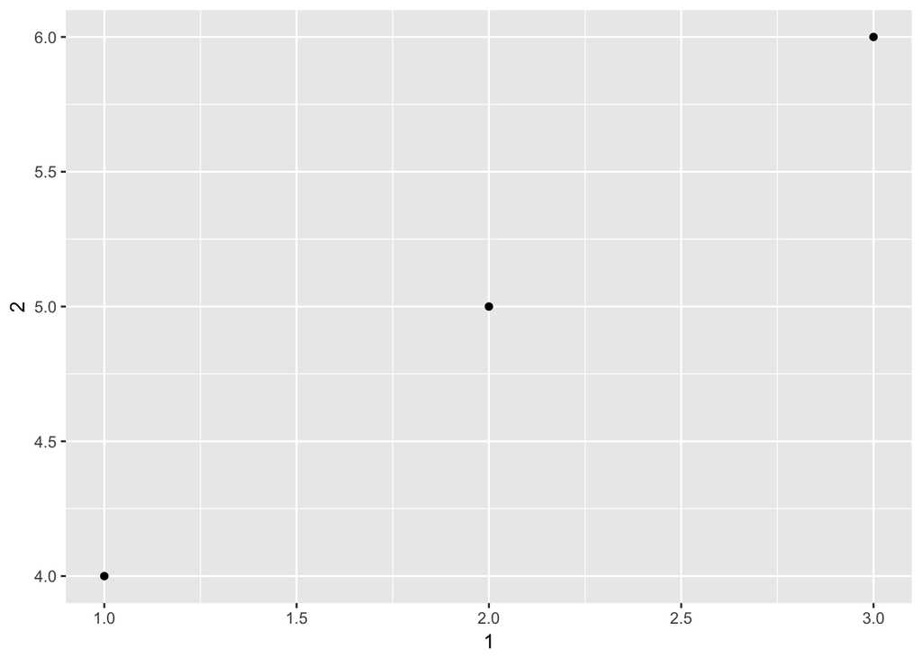

```r
tib <- tibble('1' = 1:3, '2' = 4:6)
ggplot(tib, aes(x = `1`, y = `2`)) + geom_point()
```

3. Creating a new column called 3 which is 2 divided by 1.

```r
tib <-
  tib %>%
  mutate(`3` = `2`/`1`)
```

4. Renaming the columns to one, two and three.

```r
tib %>%
  rename(one = `1`,
         two = `2`,
         three = `3`)
```

```
## # A tibble: 3 x 3
##     one   two three
##   <int> <int> <dbl>
## 1     1     4  4.00
## 2     2     5  2.50
## 3     3     6  2.00
```

5. What does tibble::enframe() do? When might you use it? enframe() takes a vector or list and converts it to a dataframe

```r
x <- c(1:5)
enframe(x)
```

```
## # A tibble: 5 x 2
##    name value
##   <int> <int>
## 1     1     1
## 2     2     2
## 3     3     3
## 4     4     4
## 5     5     5
```

```r
c <- enframe(list(a = 2, b = 3))
```

6. What option controls how many additional column names are printed at the footer of a tibble?
- tibble.max_extra_cols controls how many additional columns are printed at the end

## 12.6.1 Exercises

```r
library(tidyverse)
who1 <- who %>%
  gather(new_sp_m014:newrel_f65, key = "key", value = "cases", na.rm = TRUE)

who2 <- who1 %>%
  mutate(key = stringr::str_replace(key, "newrel", "new_rel"))

who3 <- who2 %>%
  separate(key, c("new", "type", "sexage"), sep = "_")

who4 <- who3 %>%
  select(-new, -iso2, -iso3)

who5 <- who4 %>%
  separate(sexage, c("sex", "age"), sep = 1)

who %>%
  gather(code, value, new_sp_m014:newrel_f65, na.rm = TRUE) %>%
  mutate(code = stringr::str_replace(code, "newrel", "new_rel")) %>%
  separate(code, c("new", "var", "sexage")) %>%
  select(-new, -iso2, -iso3) %>%
  separate(sexage, c("sex", "age"), sep = 1)
```

```
## # A tibble: 76,046 x 6
##    country      year var   sex   age   value
##    <chr>       <int> <chr> <chr> <chr> <int>
##  1 Afghanistan  1997 sp    m     014       0
##  2 Afghanistan  1998 sp    m     014      30
##  3 Afghanistan  1999 sp    m     014       8
##  4 Afghanistan  2000 sp    m     014      52
##  5 Afghanistan  2001 sp    m     014     129
##  6 Afghanistan  2002 sp    m     014      90
##  7 Afghanistan  2003 sp    m     014     127
##  8 Afghanistan  2004 sp    m     014     139
##  9 Afghanistan  2005 sp    m     014     151
## 10 Afghanistan  2006 sp    m     014     193
## # ... with 76,036 more rows
```

```r
who %>%
  gather(code, value, new_sp_m014:newrel_f65, na.rm = TRUE) %>%
  #mutate(code = stringr::str_replace(code, "newrel", "new_rel")) %>%
  separate(code, c("new", "var", "sexage")) %>%
  select(-new, -iso2, -iso3) %>%
  separate(sexage, c("sex", "age"), sep = 1)
```

```
## # A tibble: 76,046 x 6
##    country      year var   sex   age   value
##  * <chr>       <int> <chr> <chr> <chr> <int>
##  1 Afghanistan  1997 sp    m     014       0
##  2 Afghanistan  1998 sp    m     014      30
##  3 Afghanistan  1999 sp    m     014       8
##  4 Afghanistan  2000 sp    m     014      52
##  5 Afghanistan  2001 sp    m     014     129
##  6 Afghanistan  2002 sp    m     014      90
##  7 Afghanistan  2003 sp    m     014     127
##  8 Afghanistan  2004 sp    m     014     139
##  9 Afghanistan  2005 sp    m     014     151
## 10 Afghanistan  2006 sp    m     014     193
## # ... with 76,036 more rows
```

3. I claimed that iso2 and iso3 were redundant with country. Confirm this claim.

```r
select(who3, country, iso2, iso3) %>%
  distinct() %>%
  group_by(country) %>%
  filter(n() > 1)
```

```
## # A tibble: 0 x 3
## # Groups:   country [0]
## # ... with 3 variables: country <chr>, iso2 <chr>, iso3 <chr>
```

4. For each country, year, and sex compute the total number of cases of TB. Make an informative visualisation of the data. We can use the data from who5, which holds the sex and age variables to grab those variables and group by country,year and sex

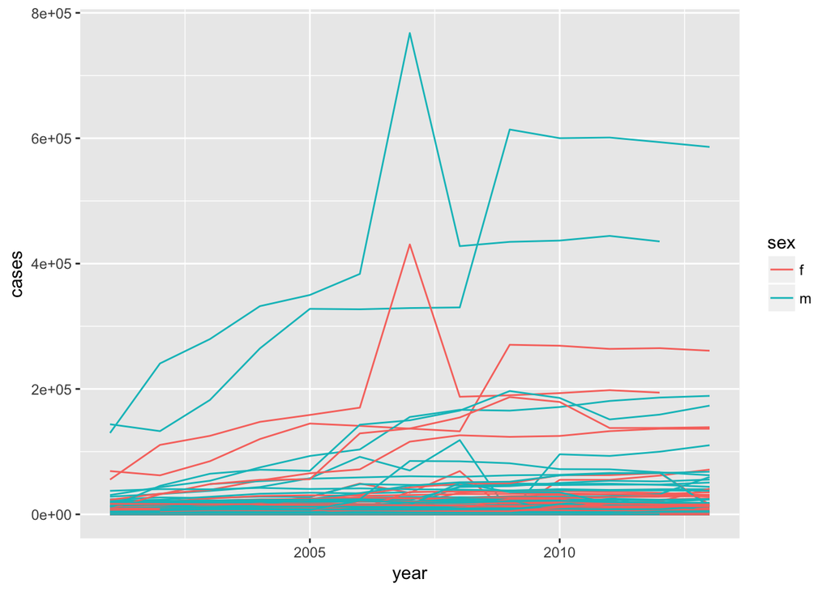

```r
who5 %>%
  group_by(country, year, sex) %>%
  filter(year > 2000) %>%
  summarise(cases = sum(cases)) %>%
  unite(country_sex, country, sex, remove=FALSE) %>%
  ggplot(aes(x = year, y = cases, group = country_sex, colour = sex)) +
  geom_line()
```

## Part 2 Tidy Data Article

```r
# path = file.path("pew.sav")
# pew = read_sav(path)
#
# religion <- pew[c("q16", "reltrad", "income")]
# religion$reltrad <- as.character(religion$reltrad)
# religion$reltrad <- str_replace(religion$reltrad, " Churches", "")
# religion$reltrad <- str_replace(religion$reltrad, " Protestant", " Prot")
# religion$reltrad[religion$q16 == " Atheist (do not believe in God) "] <- "Atheist"
# religion$reltrad[religion$q16 == " Agnostic (not sure if there is a God) "] <- "Agnostic"
# religion$reltrad <- str_trim(religion$reltrad)
# religion$reltrad <- str_replace_all(religion$reltrad, " \\(.*?\\)", "")
#
# religion$income <- c("Less than $10,000" = "<$10k",
#                      "10 to under $20,000" = "$10-20k",
#                      "20 to under $30,000" = "$20-30k",
#                      "30 to under $40,000" = "$30-40k",
#                      "40 to under $50,000" = "$40-50k",
#                      "50 to under $75,000" = "$50-75k",
#                      "75 to under $100,000" = "$75-100k",
#                      "100 to under $150,000" = "$100-150k",
#                      "$150,000 or more" = ">150k",
#                      "Don't know/Refused (VOL)" = "Don't know/refused")[religion$income]
#
# religion$income <- factor(religion$income, levels = c("<$10k", "$10-20k", "$20-30k", "$30-40k", "$40-50k", "$50-75k", "$75-100k", "$100-150k", ">150k", "Don't know/refused"))
#
# count1 <- religion %>% count(reltrad)
# count2 <- religion %>% count(q16)
# count3 <- religion %>% count(income)
# count4 <- religion %>% group_by(reltrad, q16, income) %>% count(income)
# count5 <- count4[c("reltrad", "income", "n")]
# count6 <- count5 %>% dplyr::rename(freq = n)
# count6
```

## Part 2 Tidy Data Article

4. Use dplyr and tidyr to reproduce table 7 -> table 8

```r
bb <- read.csv("billboard.csv")
bb2 <- bb %>%
  gather(week, rank, wk1:wk76, na.rm = TRUE)
bb2
```

```
##       year                       artist                   track time
## 1     2000                        2 Pac Baby Don't Cry (Keep... 4:22
## 2     2000                      2Ge+her The Hardest Part Of ... 3:15
## 3     2000                 3 Doors Down              Kryptonite 3:53
## 4     2000                 3 Doors Down                   Loser 4:24
## 5     2000                     504 Boyz           Wobble Wobble 3:35
## 6     2000                         98^0 Give Me Just One Nig... 3:24
## 7     2000                      A*Teens           Dancing Queen 3:44
## 8     2000                      Aaliyah           I Don't Wanna 4:15
## 9     2000                      Aaliyah               Try Again 4:03
## 10    2000               Adams, Yolanda           Open My Heart 5:30
## 11    2000                Adkins, Trace                    More 3:05
## 12    2000          Aguilera, Christina Come On Over Baby (A... 3:38
## 13    2000          Aguilera, Christina           I Turn To You 4:00
## 14    2000          Aguilera, Christina       What A Girl Wants 3:18
```

[output cut: 10601 more lines]